# Qualitative Activity Recognition of Weight Lifting Exercises

Elmar Langholz

June 16, 2015

## Synopsis

With the [quantified self](https://en.wikipedia.org/wiki/Quantified_Self) movement closing in on average consumers, the amount of devices and sensors available is at an all time high. These devices allow users to collect data and measure themselves over time at a very low cost. One of the areas of interest is tracking and quantifying physical activity. While there are many devices allowing this, few extend quantification to allow understanding of the quality (e.g. how well) of the physical activity that was performed. This analysis makes use of the research performed and data recollected by the [Human Activity Recognition](http://groupware.les.inf.puc-rio.br/) project with the intent of quantifying the quality of weight lifting exercises.

Through this research we found that it is possible to classify the quality of weight lifting exercises with a high degree of accuracy (0.9913, with and out-of-sample error of 0.0087) using a random forest model (trained with 52 covariates). As a point in hand, we also were able to benchmark the training time of several algorithms in which we are able to determine that depending on the prediction model the training time differs significantly across the board. Finally, reducing the dimensionality of the data generates improvements in training time.

## Data pre-processing

Two data sets were provided. The first is the [actual data set](https://d396qusza40orc.cloudfront.net/predmachlearn/pml-training.csv) used throughout this research (which does contain labeled classes) while the second is the [qualifying data set](https://d396qusza40orc.cloudfront.net/predmachlearn/pml-testing.csv) (which does not contain any classes) that is used to grade the model online for the [John Hopkins Data Science specialization](https://www.coursera.org/specialization/jhudatascience/1). We mention this because any processing done on the first should be done on the second.

The [data set](http://groupware.les.inf.puc-rio.br/har#weight_lifting_exercises) is comprised of sensor measurements of belt, forearm, arm and dumbell for six healthy candidates. The exercises cover a set of 10 repetitions of the unilateral dumbbell [bicep curls](https://en.wikipedia.org/wiki/Biceps_curl) in five different fashions. For the remainder of this document we assume that the candidate selection was random and that the sensor measurements have almost no errors.

After downloading and loading the data, we note that there are 19622 observations and 160 columns. Once we preview the data, we can determine that the columns are comprised of several columns with many not available *NA* values and besides that a majority numeric covariates. We can group them as defined in the *Types of covariates table*.

Types of covariates

| Column type | Description |
| --- | --- |
| Bookkeeping | Used to keep track of the records for accounting the observations. *E.g record number, user name, timestamps, …* |
| Raw | The [gyroscope](https://en.wikipedia.org/wiki/Gyroscope), [accelerometer](https://en.wikipedia.org/wiki/Accelerometer), [magnetometer](https://en.wikipedia.org/wiki/Magnetometer) x, y, z values and th… |
| Processed | The derived data points measures from the raw data. *E.g. max, min, avg, stddev, …* |

Since we want to build a generalizable statistical model, the bookkeeping and predominant not available covariates (having more than 40%) are removed. This reduces the amount of covariates from 159 to 52. Finally, we normalize the data by converting the class type `classe` character variable to a factor.

## Exploratory data analysis

Due to the sheer amount of variables left, its a bit difficult to recognize any patterns visually by plotting the covariates by class. Analogously, performing scatterplot matrices by sensor yields some complex relationships between each covariate pair and for which I suspect these are better ways to visualize these by using 3D scatterplots. However, since the intent of this research is to focus on prediction instead of modeling, we will leave it to the reader as an exercise.

Ultimately, we perform a variance diagnosis on the data with the intent to determine which covariates have zero o near zero variance. For which we would likely remove these variables since they wouldn’t provide any value. Nonetheless, none of these need to be removed since none comply.

## Statistical prediction/modeling

In order to perform prediction, we first slice the data in order to be able perform cross-validation since we will be evaluating the accuracy of multiple prediction models and choosing the one with the highest accuracy. Due to this, we split the data as follows:

Data slicing strategy

| Data slice | Amount | Description |
| --- | --- | --- |
| Training | 60% | Used to build the different prediction models |
| Testing | 20% | Used to estimate the accuracy of the constructed prediction model with the intent of selecting the best model |
| Validation | 20% | Used to determine the out of sample error of the best model |

Seven different prediction models where constructed and benchmarked regarding time and accuracy and the results are the ones depicted the by the tables below.

Accuracy benchmark

| Model | Accuracy | AccuracyCI |
| --- | --- | --- |
| Naive bayes | 0.7502 | (0.7363,0.7637) |
| LDA | 0.7066 | (0.6921,0.7208) |
| GLM | 0.7385 | (0.7244,0.7522) |
| kNN | 0.8919 | (0.8818,0.9015) |
| Decision Tree | 0.5175 | (0.5017,0.5332) |
| Random forest | 0.9924 | (0.9891,0.9948) |
| GBM | 0.9559 | (0.949,0.9621) |

Time benchmark

| Model | ElapsedTime |
| --- | --- |
| Naive bayes | 752.5 |
| LDA | 18.27 |
| GLM | 3202 |
| kNN | 316.9 |
| Decision Tree | 21.2 |
| Random forest | 1713 |
| GBM | 490.3 |

The **random forest** model had the highest accuracy. However, the downside of this is that the amount of time used to train the model was relatively high. The figure below shows the detected variable importance by:

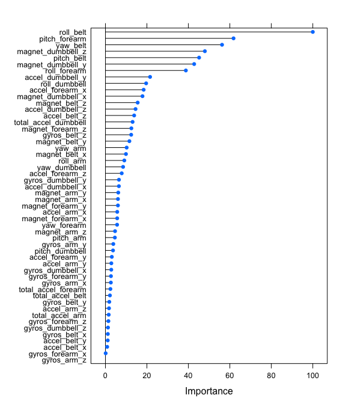

In order to reduce the amount of time spent training we compress the data by using [principal component analysis](https://en.wikipedia.org/wiki/Principal_component_analysis). This lead to 24 components which capture 95% of the variance and after rerunning the random forest model using the compressed data an accuracy of 0.9712 with a 95% confidence interval of (0.9655, 0.9762). As we can see both the accuracy was reduced by 0.0212 and the training time to 814.857 seconds. The variable importance for this model is as follows:

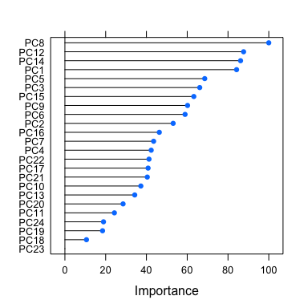

## Conclusion

Since we are interested in accuracy, the best model was the random forest prediction model (without data compression) trained using 52 covariates. It has an accuracy of 0.9913 with and out-of-sample error of 0.0087. The accuracy and out-of-sample error values were obtained by evaluating the previously unused validation data set instead of the test data set used to compare the other models. Finally, we are able to depict the accuracy through the below confusion heatmap:

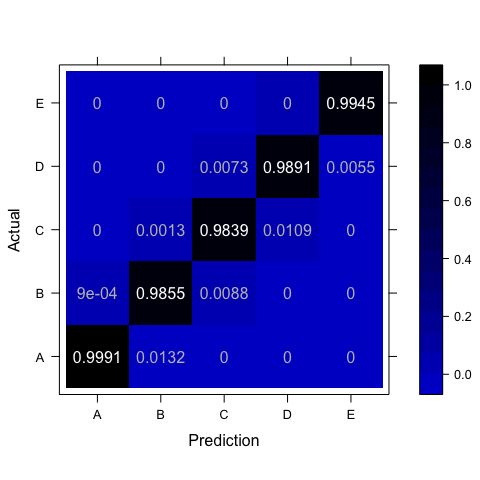

## Appendix

### 1. Data set details

#### 1.1 Sensor placement

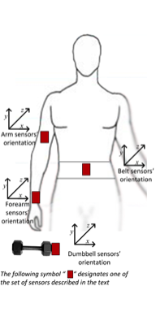

#### 1.2 Unilateral Dumbbell Biceps curl classes

Unilateral Dumbbell Biceps Curl classes

| Class | Description | Type |
| --- | --- | --- |
| A | Exactly according to the specification | Correct |
| B | Throwing the elbows to the front | Error I |
| C | Lifting the dumbbell only halfway | Error II |
| D | Lowering the dumbbell only halfway | Error III |
| E | Throwing the hips to the front | Error IV |

### 2. Download data

```r
downloadDataIfNotPresent <- function (url) {
    filePath <- paste0("./", basename(url))
    if (!file.exists(filePath)) { download.file(url, filePath, method = "curl") }
    filePath
}

setupData <- function (urls) {
    filePaths <- vapply(urls, downloadDataIfNotPresent, FUN.VALUE = character(1))
    filePaths
}

urls <- c("https://d396qusza40orc.cloudfront.net/predmachlearn/pml-training.csv",
          "https://d396qusza40orc.cloudfront.net/predmachlearn/pml-testing.csv")
filePaths <- setupData(urls)
```

### 3. Loading data

```r
data <- read.csv(filePaths[1], na.strings = c("NA", "", "#DIV/0!"), stringsAsFactors = F)
qualify <- read.csv(filePaths[2], na.strings = c("NA", "", "#DIV/0!"), stringsAsFactors = F)
```

### 4. Preview data

```r
str(data); str(qualify)
summary(data); summary(qualify)
```

### 5. Compare training and qualifying data set column names

```r
diffColumnNameIndexes <- which(!(names(qualify) %in% names(data)))
names(data)[diffColumnNameIndexes]; names(qualify)[diffColumnNameIndexes]
```

[output not shown]

```
## [1] "problem_id"
```

```r
qualify <- qualify[, !(names(qualify) %in% "problem_id")]
```

### 6. Remove bookkeeping covariates

```r
suppressedCovariateNames <- c("X", "user_name", "raw_timestamp_part_1", "raw_timestamp_part_2",
                              "cvtd_timestamp", "new_window", "num_window")
filteredData <- data[, !(names(data) %in% c(suppressedCovariateNames))]
qualify <- qualify[, !(names(qualify) %in% c(suppressedCovariateNames))]
```

### 7. Remove covariates with too many missing values

```r
covariateNARatio <- apply(filteredData[, !(names(filteredData) %in% c("classe"))],
                          2,
                          function (col, observationCount) { sum(is.na(col)) / observationCount },
                          dim(data)[1])
suppressedCovariateNames <- c(suppressedCovariateNames,
                              names(covariateNARatio)[which(covariateNARatio > 0.40)])
filteredData <- filteredData[, !(names(filteredData) %in% c(suppressedCovariateNames))]
qualify <- qualify[, !(names(qualify) %in% c(suppressedCovariateNames))]
```

### 8. Normalize data

```r
filteredData$classe <- factor(filteredData$classe)
```

### 9. Boxplots of covariates by class

```r
meltedData <- melt(filteredData, id = "classe")
classes <- c("A", "B", "C", "D", "E")
boxplotCovariatesByClass <- function (class, meltedData) {
    classData <- meltedData[which(meltedData$classe == class), ]
    plot <- ggplot(classData)
    plot <- plot + geom_boxplot(aes(x = variable, y = value))
    plot <- plot + facet_grid(. ~ classe)
    plot <- plot + theme(axis.text.x = element_text(angle = 45, hjust = 1))
    plot
}
boxplots <- lapply(classes, boxplotCovariatesByClass, meltedData)
boxplots
```

### 10. Scatterplot matrices by sensor

```r
sensors <- c("_forearm", "_arm", "_dumbbell", "_belt")
scatterplotMatrixBySensor <- function (sensor, data, names) {
    indices <- c(which(grepl(sensor, names)), which(grepl("classe", names)))
    sensorData <- data[, indices]
    scatterplotMatrix(sensorData)
}
lapply(sensors, scatterplotMatrixBySensor, filteredData, names(filteredData))
```

### 11. Covariates with zero or near zero variance

```r
covariateVariance <- nearZeroVar(
    filteredData[, !(names(filteredData) %in% c("classe"))],
    saveMetrics = TRUE)
zeroOrNearZeroVarIndices <- which(covariateVariance$zeroVar | covariateVariance$nzv)
```

### 12. Slice data set

```r
char2seed("d[o_0]b")
dataSetIndices <- createDataPartition(filteredData$classe, p = 3 / 5, list = F)
train <- filteredData[dataSetIndices, ]
crossValidation <- filteredData[-dataSetIndices, ]
testSetIndices <- createDataPartition(crossValidation$classe, p = 1 / 2, list = F)
test <- crossValidation[testSetIndices, ]
validation <- crossValidation[-testSetIndices, ]
```

### 13. Data compression using Principal Component Analysis

```r
trainCompression <- preProcess(train[, !(names(train) %in% c("classe"))],
                               method = c("BoxCox", "center", "scale", "pca"),
                               thresh = 0.95)
trainWithCompression <- predict(trainCompression, train[, !(names(train) %in% c("classe"))])
testWithCompression <- predict(trainCompression, test[, !(names(test) %in% c("classe"))])
validationWithCompression <- predict(trainCompression, validation[, !(names(validation) %in% c("classe"))])
qualifyWithCompression <- predict(trainCompression, qualify[, !(names(qualify) %in% c("problem_id"))])
```

### 14. Naive bayes model

```r
char2seed("d[o_0]b")
nbStartTime <- proc.time()
nbFit <- train(classe ~ ., method = "nb", data = train)
nbTrainingTime <- proc.time() - nbStartTime
nbFitPrediction <- predict(nbFit, test)
nbConfusionMatrix <- confusionMatrix(nbFitPrediction, test$classe)
```

```
##    user  system elapsed
##   0.988   0.058 752.460
```

```
## Confusion Matrix and Statistics
##
##           Reference
## Prediction   A   B   C   D   E
##          A 996 152 156 134  38
##          B  31 514  49   0  59
##          C  33  52 463  73  30
##          D  52  33  14 397  21
##          E   4   8   2  39 573
##
## Overall Statistics
##
##                Accuracy : 0.7502
##                  95% CI : (0.7363, 0.7637)
##     No Information Rate : 0.2845
##     P-Value [Acc > NIR] : < 2.2e-16
##
##                   Kappa : 0.6801
##  Mcnemar's Test P-Value : < 2.2e-16
##
## Statistics by Class:
##
##                      Class: A Class: B Class: C Class: D Class: E
## Sensitivity            0.8925   0.6772   0.6769   0.6174   0.7947
## Specificity            0.8290   0.9561   0.9420   0.9634   0.9834
## Pos Pred Value         0.6748   0.7871   0.7112   0.7679   0.9153
## Neg Pred Value         0.9510   0.9251   0.9325   0.9278   0.9551
## Prevalence             0.2845   0.1935   0.1744   0.1639   0.1838
## Detection Rate         0.2539   0.1310   0.1180   0.1012   0.1461
## Detection Prevalence   0.3762   0.1665   0.1659   0.1318   0.1596
## Balanced Accuracy      0.8607   0.8166   0.8094   0.7904   0.8891
```

### 15. Linear discriminant analysis model

```r
char2seed("d[o_0]b")
ldaStartTime <- proc.time()
ldaFit <- train(classe ~ ., method = "lda", data = train)
ldaTrainingTime <- proc.time() - ldaStartTime
ldaFitPrediction <- predict(ldaFit, test)
ldaConfusionMatrix <- confusionMatrix(ldaFitPrediction, test$classe)
```

```
##    user  system elapsed
##   0.984   0.065  18.265
```

```
## Confusion Matrix and Statistics
##
##           Reference
## Prediction   A   B   C   D   E
##          A 912 119  68  43  23
##          B  28 483  65  27 128
##          C  76  87 462  73  68
##          D  95  29  70 477  64
##          E   5  41  19  23 438
##
## Overall Statistics
##
##                Accuracy : 0.7066
##                  95% CI : (0.6921, 0.7208)
##     No Information Rate : 0.2845
##     P-Value [Acc > NIR] : < 2.2e-16
##
##                   Kappa : 0.6286
##  Mcnemar's Test P-Value : < 2.2e-16
##
## Statistics by Class:
##
##                      Class: A Class: B Class: C Class: D Class: E
## Sensitivity            0.8172   0.6364   0.6754   0.7418   0.6075
## Specificity            0.9099   0.9216   0.9061   0.9213   0.9725
## Pos Pred Value         0.7828   0.6607   0.6031   0.6490   0.8327
## Neg Pred Value         0.9260   0.9135   0.9297   0.9479   0.9167
## Prevalence             0.2845   0.1935   0.1744   0.1639   0.1838
## Detection Rate         0.2325   0.1231   0.1178   0.1216   0.1116
## Detection Prevalence   0.2970   0.1863   0.1953   0.1874   0.1341
## Balanced Accuracy      0.8635   0.7790   0.7908   0.8316   0.7900
```

### 16. Generlized linear model

```r
char2seed("d[o_0]b")
glmnetStartTime <- proc.time()
glmnetFit <- train(classe ~ ., method = "glmnet", data = train,
                   tuneGrid = expand.grid(.alpha= seq(0, 1, 0.5), .lambda = 0:30 / 10))
glmnetTrainingTime <- proc.time() - glmnetStartTime
glmnetFitPrediction <- predict(glmnetFit, test)
glmnetConfusionMatrix <- confusionMatrix(glmnetFitPrediction, test$classe)
```

```
##     user   system  elapsed
##  194.917    0.640 3202.489
```

```
## Confusion Matrix and Statistics
##
##           Reference
## Prediction   A   B   C   D   E
##          A 959  94  55  45  35
##          B  44 503  65  33  93
##          C  52  67 495  81  45
##          D  50  26  42 448  56
##          E  11  69  27  36 492
##
## Overall Statistics
##
##                Accuracy : 0.7385
##                  95% CI : (0.7244, 0.7522)
##     No Information Rate : 0.2845
##     P-Value [Acc > NIR] : < 2.2e-16
##
##                   Kappa : 0.6685
##  Mcnemar's Test P-Value : 1.574e-08
##
## Statistics by Class:
##
##                      Class: A Class: B Class: C Class: D Class: E
## Sensitivity            0.8593   0.6627   0.7237   0.6967   0.6824
## Specificity            0.9184   0.9257   0.9244   0.9470   0.9553
## Pos Pred Value         0.8072   0.6816   0.6689   0.7203   0.7748
## Neg Pred Value         0.9426   0.9196   0.9406   0.9409   0.9304
## Prevalence             0.2845   0.1935   0.1744   0.1639   0.1838
## Detection Rate         0.2445   0.1282   0.1262   0.1142   0.1254
## Detection Prevalence   0.3028   0.1881   0.1886   0.1586   0.1619
## Balanced Accuracy      0.8889   0.7942   0.8240   0.8218   0.8189
```

### 17. K-Nearest Neighbour model

```r
char2seed("d[o_0]b")
knnStartTime <- proc.time()
knnFit <- train(classe ~ ., method = "knn", data = train)
knnTrainingTime <- proc.time() - knnStartTime
knnFitPrediction <- predict(knnFit, test)
knnConfusionMatrix <- confusionMatrix(knnFitPrediction, test$classe)
```

```
##    user  system elapsed
##   0.711   0.040 316.880
```

```
## Confusion Matrix and Statistics
##
##           Reference
## Prediction    A    B    C    D    E
##          A 1047   42   12   13   15
##          B   16  647   19    9   28
##          C   12   24  620   55   26
##          D   31   27   24  560   27
##          E   10   19    9    6  625
##
## Overall Statistics
##
##                Accuracy : 0.8919
##                  95% CI : (0.8818, 0.9015)
##     No Information Rate : 0.2845
##     P-Value [Acc > NIR] : < 2.2e-16
##
##                   Kappa : 0.8633
##  Mcnemar's Test P-Value : 3.863e-10
##
## Statistics by Class:
##
##                      Class: A Class: B Class: C Class: D Class: E
## Sensitivity            0.9382   0.8524   0.9064   0.8709   0.8669
## Specificity            0.9708   0.9772   0.9639   0.9668   0.9863
## Pos Pred Value         0.9274   0.8999   0.8412   0.8371   0.9342
## Neg Pred Value         0.9753   0.9650   0.9799   0.9745   0.9705
## Prevalence             0.2845   0.1935   0.1744   0.1639   0.1838
## Detection Rate         0.2669   0.1649   0.1580   0.1427   0.1593
## Detection Prevalence   0.2878   0.1833   0.1879   0.1705   0.1705
## Balanced Accuracy      0.9545   0.9148   0.9352   0.9188   0.9266
```

### 18. Decision tree model

```r
char2seed("d[o_0]b")
rpartStartTime <- proc.time()
rpartFit <- train(classe ~ ., method = "rpart", data = train)
rpartTrainingTime <- proc.time() - rpartStartTime
rpartFitPrediction <- predict(rpartFit, test)
rpartConfusionMatrix <- confusionMatrix(rpartFitPrediction, test$classe)
```

```
##    user  system elapsed
##   5.418   0.063  21.197
```

```
## Confusion Matrix and Statistics
##
##           Reference
## Prediction   A   B   C   D   E
##          A 670 118  21  24   9
##          B 219 482 108 275 216
##          C 222 159 555 344 173
##          D   0   0   0   0   0
##          E   5   0   0   0 323
##
## Overall Statistics
##
##                Accuracy : 0.5175
##                  95% CI : (0.5017, 0.5332)
##     No Information Rate : 0.2845
##     P-Value [Acc > NIR] : < 2.2e-16
##
##                   Kappa : 0.3929
##  Mcnemar's Test P-Value : NA
##
## Statistics by Class:
##
##                      Class: A Class: B Class: C Class: D Class: E
## Sensitivity            0.6004   0.6350   0.8114   0.0000  0.44799
## Specificity            0.9387   0.7415   0.7228   1.0000  0.99844
## Pos Pred Value         0.7957   0.3708   0.3820      NaN  0.98476
## Neg Pred Value         0.8552   0.8944   0.9478   0.8361  0.88929
## Prevalence             0.2845   0.1935   0.1744   0.1639  0.18379
## Detection Rate         0.1708   0.1229   0.1415   0.0000  0.08233
## Detection Prevalence   0.2146   0.3314   0.3704   0.0000  0.08361
## Balanced Accuracy      0.7695   0.6883   0.7671   0.5000  0.72321
```

### 19. Random forest model

```r
char2seed("d[o_0]b")
rfStartTime <- proc.time()
rfFit <- train(classe ~ ., method = "rf", data = train)
rfTrainingTime <- proc.time() - rfStartTime
rfFitPrediction <- predict(rfFit, test)
rfConfusionMatrix <- confusionMatrix(rfFitPrediction, test$classe)
```

```
##     user   system  elapsed
##   44.359    0.339 1712.970
```

```
## Confusion Matrix and Statistics
##
##           Reference
## Prediction    A    B    C    D    E
##          A 1115   11    0    0    0
##          B    1  746    3    0    0
##          C    0    2  677    8    1
##          D    0    0    4  635    0
##          E    0    0    0    0  720
##
## Overall Statistics
##
##                Accuracy : 0.9924
##                  95% CI : (0.9891, 0.9948)
##     No Information Rate : 0.2845
##     P-Value [Acc > NIR] : < 2.2e-16
##
##                   Kappa : 0.9903
##  Mcnemar's Test P-Value : NA
##
## Statistics by Class:
##
##                      Class: A Class: B Class: C Class: D Class: E
## Sensitivity            0.9991   0.9829   0.9898   0.9876   0.9986
## Specificity            0.9961   0.9987   0.9966   0.9988   1.0000
## Pos Pred Value         0.9902   0.9947   0.9840   0.9937   1.0000
## Neg Pred Value         0.9996   0.9959   0.9978   0.9976   0.9997
## Prevalence             0.2845   0.1935   0.1744   0.1639   0.1838
## Detection Rate         0.2842   0.1902   0.1726   0.1619   0.1835
## Detection Prevalence   0.2870   0.1912   0.1754   0.1629   0.1835
## Balanced Accuracy      0.9976   0.9908   0.9932   0.9932   0.9993
```

### 20. Generalized boosted regression model

```r
char2seed("d[o_0]b")
gbmStartTime <- proc.time()
gbmFit <- train(classe ~ ., method="gbm", data = train, verbose = F)
gbmTrainingTime <- proc.time() - gbmStartTime
gbmFitPrediction <- predict(gbmFit, test)
gbmConfusionMatrix <- confusionMatrix(gbmFitPrediction, test$classe)
```

```
##    user  system elapsed
##  22.468   0.213 490.334
```

```
## Confusion Matrix and Statistics
##
##           Reference
## Prediction    A    B    C    D    E
##          A 1090   31    0    2    1
##          B   18  708   22    1    3
##          C    2   19  650   25   11
##          D    3    0   11  610   14
##          E    3    1    1    5  692
##
## Overall Statistics
##
##                Accuracy : 0.9559
##                  95% CI : (0.949, 0.9621)
##     No Information Rate : 0.2845
##     P-Value [Acc > NIR] : < 2.2e-16
##
##                   Kappa : 0.9442
##  Mcnemar's Test P-Value : 0.002692
##
## Statistics by Class:
##
##                      Class: A Class: B Class: C Class: D Class: E
## Sensitivity            0.9767   0.9328   0.9503   0.9487   0.9598
## Specificity            0.9879   0.9861   0.9824   0.9915   0.9969
## Pos Pred Value         0.9698   0.9415   0.9194   0.9561   0.9858
## Neg Pred Value         0.9907   0.9839   0.9894   0.9900   0.9910
## Prevalence             0.2845   0.1935   0.1744   0.1639   0.1838
## Detection Rate         0.2778   0.1805   0.1657   0.1555   0.1764
## Detection Prevalence   0.2865   0.1917   0.1802   0.1626   0.1789
## Balanced Accuracy      0.9823   0.9594   0.9663   0.9701   0.9783
```

### 21. Random forest regression model with compressed data

```r
char2seed("d[o_0]b")
rfWithPCAStartTime <- proc.time()
rfWithPCAFit <- train(train$classe ~ ., method = "rf", data = trainWithCompression)
rfWithPCATrainingTime <- proc.time() - rfWithPCAStartTime
rfWithPCAFitPrediction <- predict(rfWithPCAFit, testWithCompression)
rfWithPCAConfusionMatrix <- confusionMatrix(rfWithPCAFitPrediction, test$classe)
```

```
##    user  system elapsed
##  17.039   0.230 814.857
```

```
## Confusion Matrix and Statistics
##
##           Reference
## Prediction    A    B    C    D    E
##          A 1104   25    0    1    0
##          B    4  725    7    3    4
##          C    3    9  668   29    5
##          D    5    0    8  607    6
##          E    0    0    1    3  706
##
## Overall Statistics
##
##                Accuracy : 0.9712
##                  95% CI : (0.9655, 0.9762)
##     No Information Rate : 0.2845
##     P-Value [Acc > NIR] : < 2.2e-16
##
##                   Kappa : 0.9636
##  Mcnemar's Test P-Value : NA
##
## Statistics by Class:
##
##                      Class: A Class: B Class: C Class: D Class: E
## Sensitivity            0.9892   0.9552   0.9766   0.9440   0.9792
## Specificity            0.9907   0.9943   0.9858   0.9942   0.9988
## Pos Pred Value         0.9770   0.9758   0.9356   0.9696   0.9944
## Neg Pred Value         0.9957   0.9893   0.9950   0.9891   0.9953
## Prevalence             0.2845   0.1935   0.1744   0.1639   0.1838
## Detection Rate         0.2814   0.1848   0.1703   0.1547   0.1800
## Detection Prevalence   0.2880   0.1894   0.1820   0.1596   0.1810
## Balanced Accuracy      0.9900   0.9748   0.9812   0.9691   0.9890
```

### 22. Random forest cross-validation

```r
rfValidationPrediction <- predict(rfFit, validation)
rfValidationConfusionMatrix <- confusionMatrix(rfValidationPrediction, validation$classe)
```

### 23. Random forest with compression cross-validation

```r
rfValidationWithPCAPrediction <- predict(rfWithPCAFit, validationWithCompression)
rfValidationWithPCAConfusionMatrix <- confusionMatrix(rfValidationWithPCAPrediction, validation$classe)
```

### 24. Qualification results

```r
writePredictions <- function (results) {
    fileWrite <- function (index, r) {
        fileName <- paste0("./problem_id_", index, ".txt")
        write.table(r[index], file = fileName, quote = F, row.names = F, col.names = F)
        fileName
    }
    filePaths <- vapply(1:length(results), fileWrite, FUN.VALUE = character(1), results)
    filePaths
}

results <- predict(rfFit, qualify)
filePaths <- writePredictions(results)
```